# NYPD Shooting Incident Data (Historic)

Kath Nguyen

12/5/2021

## ## Project Step 1: Start an Rmd Document

For this portion of the project, the first step was to ensure that the `tidyverse` package would be accessible to run the codes necessary to analyze this data using the `library()` function. From there, the data set, “NYPD Shooting Incident Data (Historic)”, was imported using the url (https://data.cityofnewyork.us/api/views/833y-fsy8/rows.csv?accessType=DOWNLOAD). The url was then assigned the variable “NYPD_data_url” to simplify the csv file to tibble conversion.

```r
#Import NYPD Shooting Incident Data (Historic) URL

library(tidyverse)
library(lubridate)
NYPD_data_url <- "https://data.cityofnewyork.us/api/views/833y-fsy8/rows.csv?accessType=DOWNLOAD"
```

Thereafter, the **NYPD_data_url** variable was placed into a `read_csv()` function to properly convert the data csv file into a tibble.

```r
#Import NYPD Shooting Incident Data (Historic) as csv
#Read as tibble
NYPD_data <- read_csv(NYPD_data_url)
NYPD_data
```

```
## # A tibble: 23,585 x 19
##    INCIDENT_KEY OCCUR_DATE OCCUR_TIME BORO     PRECINCT JURISDICTION_CODE
##           <dbl> <chr>      <time>     <chr>       <dbl>             <dbl>
##  1     24050482 08/27/2006 05:35      BRONX          52                 0
##  2     77673979 03/11/2011 12:03      QUEENS        106                 0
##  3    203350417 10/06/2019 01:09      BROOKLYN       77                 0
##  4     80584527 09/04/2011 03:35      BRONX          40                 0
##  5     90843766 05/27/2013 21:16      QUEENS        100                 0
##  6     92393427 09/01/2013 04:17      BROOKLYN       67                 0
##  7     73057167 06/05/2010 21:16      BROOKLYN       77                 0
##  8    211362213 03/20/2020 21:27      BROOKLYN       81                 0
##  9    137564752 07/04/2014 00:25      QUEENS        101                 0
## 10    147024011 10/18/2015 01:33      QUEENS        106                 0
## # ... with 23,575 more rows, and 13 more variables: LOCATION_DESC <chr>,
## #   STATISTICAL_MURDER_FLAG <lgl>, PERP_AGE_GROUP <chr>, PERP_SEX <chr>,
## #   PERP_RACE <chr>, VIC_AGE_GROUP <chr>, VIC_SEX <chr>, VIC_RACE <chr>,
## #   X_COORD_CD <dbl>, Y_COORD_CD <dbl>, Latitude <dbl>, Longitude <dbl>,
## #   Lon_Lat <chr>
```

This data set lists all shooting incident that occurred in New York City from last year dating back to 2006. Furthermore, the data set provides numeric and non-numeric data for each variable related to the shooting incidents. Thus far in this data set, there should be the following variables/factors:

- INCIDENT KEY
- OCCUR_DATE
- OCCUR_TIME
- BORO
- PRECINCT
- JURISDICTION_CODE
- LOCATION_DESC
- STATISTICAL_MURDER_FLAG
- PERP_AGE_GROUP
- PERP_SEX
- PERP_RACE
- VIC_AGE_GROUP
- VIC_SEX
- VIC_RACE
- X_COORD_CD
- Y_COORD_CD
- Latitude
- Longitude
- Lon_Lat

Given this data, it will be used to investigate whether race, sex, and borough location are factors that may have led to these shooting incidents over the years.

## ## Project Step 2: Tidy and Transform Data

For this second portion, data needs to be wrangled in a way that is cleaner and more concise. Before doing so, a preview of the data is necessary to check if there is missing data.

```r
View(NYPD_data) #preview whole data
summary(NYPD_data)
```

```
##   INCIDENT_KEY        OCCUR_DATE         OCCUR_TIME           BORO
##  Min.   :  9953245   Length:23585       Length:23585      Length:23585
##  1st Qu.: 55322804   Class :character   Class1:hms        Class :character
##  Median : 83435362   Mode  :character   Class2:difftime   Mode  :character
##  Mean   :102280741                      Mode  :numeric
##  3rd Qu.:150911774
##  Max.   :230611229
##
##     PRECINCT      JURISDICTION_CODE LOCATION_DESC      STATISTICAL_MURDER_FLAG
##  Min.   :  1.00   Min.   :0.000     Length:23585       Mode :logical
##  1st Qu.: 44.00   1st Qu.:0.000     Class :character   FALSE:19085
##  Median : 69.00   Median :0.000     Mode  :character   TRUE :4500
##  Mean   : 66.21   Mean   :0.333
##  3rd Qu.: 81.00   3rd Qu.:0.000
##  Max.   :123.00   Max.   :2.000
##                   NA's   :2
##  PERP_AGE_GROUP       PERP_SEX          PERP_RACE         VIC_AGE_GROUP
##  Length:23585       Length:23585       Length:23585       Length:23585
##  Class :character   Class :character   Class :character   Class :character
##  Mode  :character   Mode  :character   Mode  :character   Mode  :character
##
##
##
##
##    VIC_SEX            VIC_RACE           X_COORD_CD        Y_COORD_CD
##  Length:23585       Length:23585       Min.   : 914928   Min.   :125757
##  Class :character   Class :character   1st Qu.: 999925   1st Qu.:182539
##  Mode  :character   Mode  :character   Median :1007654   Median :193470
##                                        Mean   :1009379   Mean   :207300
##                                        3rd Qu.:1016782   3rd Qu.:239163
##                                        Max.   :1066815   Max.   :271128
##
##     Latitude       Longitude        Lon_Lat
##  Min.   :40.51   Min.   :-74.25   Length:23585
##  1st Qu.:40.67   1st Qu.:-73.94   Class :character
##  Median :40.70   Median :-73.92   Mode  :character
##  Mean   :40.74   Mean   :-73.91
##  3rd Qu.:40.82   3rd Qu.:-73.88
##  Max.   :40.91   Max.   :-73.70
##
```

Based on the data/summary and the purpose of this investigation, evidently coordinates, latitude/longitude, time, age, locations, codes, and incident key information will not be needed; therefore they will be removed. Furthermore, considering that majority of the data listed for perpetrators are N/A, it will not be used for analysis and will be removed as well. This first code helps tidy up all the excess data using the functions in the `tidyverse` library.

```r
#Remove: INCIDENT_KEY, OCCUR_TIME, BORO, PRECINCT, JURISDICTION_CODE, LOCATION_DESC, STATISTICAL_MURDER_FLAG, PERP_AGE_GROUP,PERP_SEX,PERP_RACE, VIC_AGE_GROUP, X_COORD_CD, Y_COORD_CD, Latitude, Longitude, Lon_Lat

tidy_NYPD_data <- NYPD_data %>%
  select(-c(INCIDENT_KEY,
            OCCUR_TIME,
            PRECINCT,
            JURISDICTION_CODE,
            LOCATION_DESC,
            STATISTICAL_MURDER_FLAG,
            PERP_AGE_GROUP,
            PERP_SEX,
            PERP_RACE,
            VIC_AGE_GROUP,
            X_COORD_CD,
            Y_COORD_CD,
            Latitude,
            Longitude,
            Lon_Lat))

tidy_NYPD_data
```

```
## # A tibble: 23,585 x 4
##    OCCUR_DATE BORO     VIC_SEX VIC_RACE
##    <chr>      <chr>    <chr>   <chr>
##  1 08/27/2006 BRONX    F       BLACK HISPANIC
##  2 03/11/2011 QUEENS   M       WHITE
##  3 10/06/2019 BROOKLYN F       BLACK
##  4 09/04/2011 BRONX    M       BLACK
##  5 05/27/2013 QUEENS   M       BLACK
##  6 09/01/2013 BROOKLYN M       BLACK
##  7 06/05/2010 BROOKLYN M       BLACK
##  8 03/20/2020 BROOKLYN M       BLACK
##  9 07/04/2014 QUEENS   M       BLACK
## 10 10/18/2015 QUEENS   M       BLACK
## # ... with 23,575 more rows
```

```r
summary(tidy_NYPD_data) #summarize the data
```

```
##   OCCUR_DATE            BORO             VIC_SEX            VIC_RACE
##  Length:23585       Length:23585       Length:23585       Length:23585
##  Class :character   Class :character   Class :character   Class :character
##  Mode  :character   Mode  :character   Mode  :character   Mode  :character
```

After condensing as much as possible in the previous code, it was necessary to find summarize the data, using the `summary()` function, to ensure all the data is correct. Unfortunately, since the **OCCUR_DATE** column was not classified as a *date* but as a *character*, this column needed to be manipulated into a *date* classified column. This process can be seen in the following code chunk.

```r
#convert the OCCUR_DATE column from character to date class
tidy_NYPD_data_date <- tidy_NYPD_data %>%
  rename(Borough = BORO,
         Victim_Sex = VIC_SEX,
         Victim_Race = VIC_RACE) %>%
  mutate(Date = as.Date(OCCUR_DATE, "%m/%d/%Y")) %>%
  select(-c(OCCUR_DATE))
tidy_NYPD_data_date
```

```
## # A tibble: 23,585 x 4
##    Borough  Victim_Sex Victim_Race    Date
##    <chr>    <chr>      <chr>          <date>
##  1 BRONX    F          BLACK HISPANIC 2006-08-27
##  2 QUEENS   M          WHITE          2011-03-11
##  3 BROOKLYN F          BLACK          2019-10-06
##  4 BRONX    M          BLACK          2011-09-04
##  5 QUEENS   M          BLACK          2013-05-27
##  6 BROOKLYN M          BLACK          2013-09-01
##  7 BROOKLYN M          BLACK          2010-06-05
##  8 BROOKLYN M          BLACK          2020-03-20
##  9 QUEENS   M          BLACK          2014-07-04
## 10 QUEENS   M          BLACK          2015-10-18
## # ... with 23,575 more rows
```

As shown above, column **Date** was created in place of **OCCUR_DATE**.

For the next portion, to simplify the data for analysis, rather than using the actual dates in the the **Date** column, it was simpler to utilize only the years. So the **Date** column needed to be simplified into a **Year** column.

```r
tidy_NYPD_data_final <- tidy_NYPD_data_date%>%
  mutate(Year = format(Date, "%Y")) %>%
  group_by(Borough, Victim_Sex, Victim_Race, Year) %>%
  summarise(name_count = n())%>%
  select(Borough,
         Victim_Sex,
         Victim_Race,
         Year)%>%
  ungroup()
tidy_NYPD_data_final
```

```
## # A tibble: 649 x 4
##    Borough Victim_Sex Victim_Race Year
##    <chr>   <chr>      <chr>       <chr>
##  1 BRONX   F          BLACK       2006
##  2 BRONX   F          BLACK       2007
##  3 BRONX   F          BLACK       2008
##  4 BRONX   F          BLACK       2009
##  5 BRONX   F          BLACK       2010
##  6 BRONX   F          BLACK       2011
##  7 BRONX   F          BLACK       2012
##  8 BRONX   F          BLACK       2013
##  9 BRONX   F          BLACK       2014
## 10 BRONX   F          BLACK       2015
## # ... with 639 more rows
```

Alas, the data was finally being tidy and ready for analysis, which leads to the next part of the data science process: visualize and model the data.

## ## Project Step 3: Add Visualizations and Analysis

For this portion of the project, visualizations in relation to the investigation are necessary for understanding what the data representing, as well as potentially acknowledging potential external factors. To investigate whether race, sex, and borough location are contributing factors of shooting incidents, histograms were made for each variable, in respect to **Year**.

### Visualization 1: Borough Location of Shooting Victims Histogram

*Histograms*

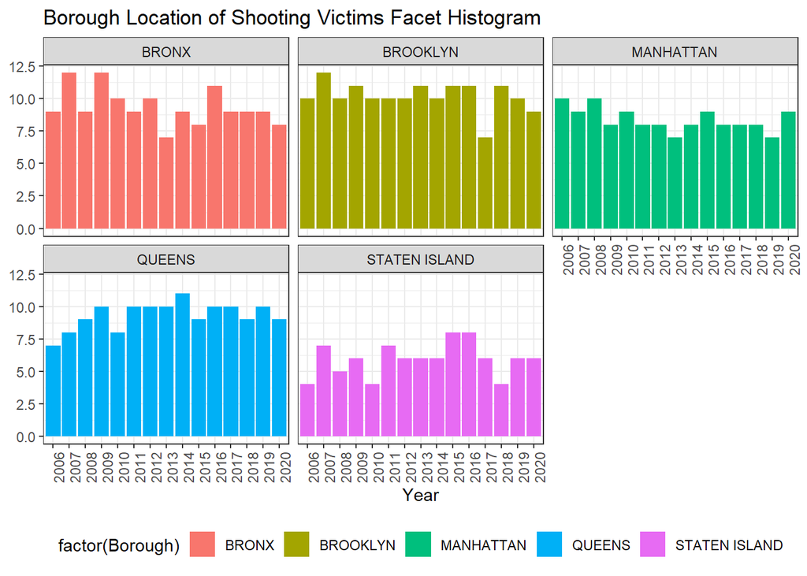

```r
ggplot(tidy_NYPD_data_final,aes(x=Year, group=Borough, fill=factor(Borough)))+
   geom_histogram(stat = "count",
   position="dodge", bins = 10)+
   theme_bw()+
   facet_wrap(Borough~.) +
   theme(legend.position = "bottom",
        axis.text.x = element_text (angle = 90)) +
   labs(title = str_c("Borough Location of Shooting Victims Facet Histogram"),
       y = NULL)
```

### Visualization 2: Sex of Shooting Victims Histogram

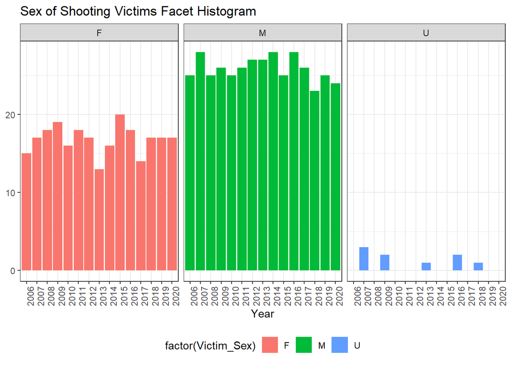

```r
ggplot(tidy_NYPD_data_final,aes(x=Year,group=Victim_Sex, fill=factor(Victim_Sex)))+
   geom_histogram(stat = "count",
   position="dodge", bins = 10)+
   theme_bw()+
   facet_wrap(Victim_Sex~.) +
   theme(legend.position = "bottom",
        axis.text.x = element_text (angle = 90)) +
   labs(title = str_c("Sex of Shooting Victims Facet Histogram"),
       y = NULL)
```

**Analysis 2: Sex of Shooting Victims Histogram** For this graph, the male histogram of NYC shootings are clearly higher than females, no matter what year it was for the past 15 years. Since all the male histogram bars in each year are taller than female, it is evident that between the two sexes, male have a higher chance of encountering a shooting incident compared to a women. In result, sex is likely a factor that plays into how likely one is going to become a victim in shootings.

### Visualization 3: Race of Shooting Victims Facet Histogram

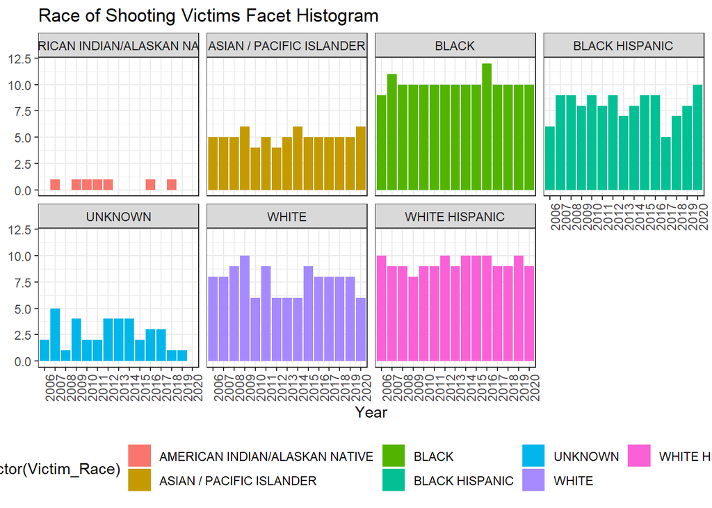

```r
ggplot(tidy_NYPD_data_final,aes(x=Year,group=Victim_Race, fill=factor(Victim_Race)))+
   geom_histogram(stat = "count",
   position="dodge", bins = 10)+
   theme_bw()+
   facet_wrap(Victim_Race~., nrow=2) +
   theme(legend.position = "bottom",
        axis.text.x = element_text (angle = 90)) +
   labs(title = str_c("Race of Shooting Victims Facet Histogram"),
       y = NULL)
```

**Analysis 3: Race of Shooting Victims Facet Histogram** Similarly to the histograms for Borough Locations, the average count for each respective racial group is about the same, meaning all the racial groups have some sort of uniformity when it comes to representation in NYC. Based on solely this information, this shows consistency throughout the years of racial groups involved in shooting incidents, which could mean that racism does not necessarily play a role in shooting incidents because the proportion of those victims remain the same over the years. However, on the contrary, considering that Blacks, White Hispanics, and Black Hispanics are the ones with the highest count shooting victims, it could indicate racism plays a role in these incidents because they have the highest counts consistently. Without any knowledge of how prominent these races are relative to their population, it could easily be misunderstood. Therefore, based on this, race can play a role towards who the victims are in these shooting accidents; however, there is not enough evidence in this data set to prove this as a strong factor. In result, this variable is likely a potential factor but not a definite factor for instigating these shooting incidents. Therefore, among these three histograms, it is likely there are other potential factors that contribute to the shooting incidents overall.

*Plot Comparisons* ### Visualization 4: Borough Location and Sex of Shooting Victims In this data, the Borough locations were graphed by year relative to sex.

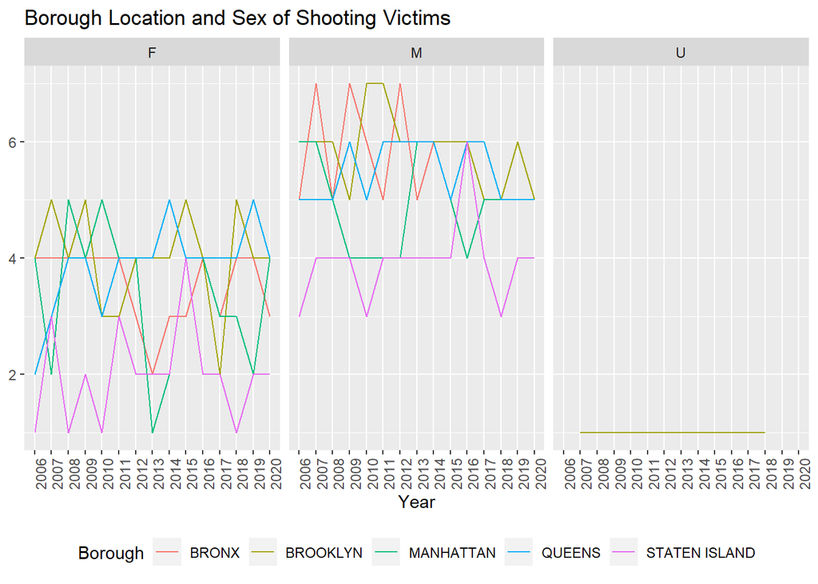

```r
ggplot(tidy_NYPD_data_final,aes(x=Year,
                                group=Borough,
                                colour = Borough))+
   geom_freqpoly(stat = "count",
   position="dodge", bins = 10)+
  facet_wrap(Victim_Sex~.)+
  theme(legend.position = "bottom",
        axis.text.x = element_text (angle = 90)) +
  labs(title = str_c("Borough Location and Sex of Shooting Victims"),
       y = NULL)
```

**Analysis 4: Borough Location and Sex of Shooting Victims** With two variables displayed in this plot, it is evident that the count of victims based on borough location is about the same hierarchy as the one demonstrated in visualization 1. However, despite some differences in plot for each location, the overall count of male victims stays true across all places. This means that regardless of where the shooting happens, males are at high risk of becoming victims to them, which also matches the analysis of those factors individually on the histogram. Therefore, sex can determine the chances of a person becoming a victim to shooting, regardless of that individuals where the crime may take place.

### Visualization 5: Race and Borough Location of Shooting Victims

In this data, each race was graphed by year, relative to Borough Location..

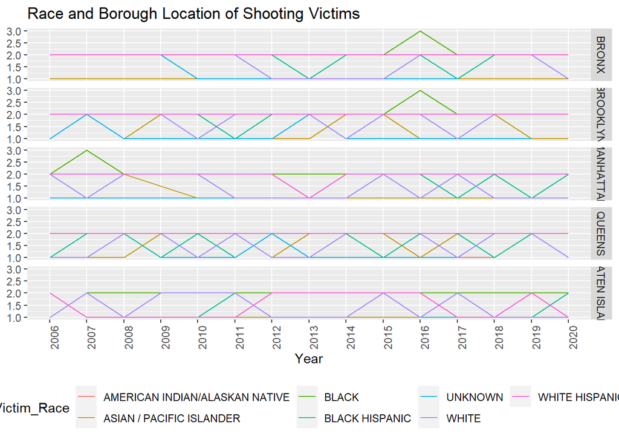

```r
ggplot(tidy_NYPD_data_final,aes(x=Year,
                                group=Victim_Race,
                                colour = Victim_Race))+
   geom_freqpoly(stat = "count",
   position="dodge", bins = 10)+
  facet_grid(Borough~.)+
  theme(legend.position = "bottom",
        axis.text.x = element_text (angle = 90)) +
  labs(title = str_c("Race and Borough Location of Shooting Victims"),
       y = NULL)
```

**Analysis 5: Race and Borough Location of Shooting Victims** The outcome of this graph does not indicate any sort of difference between victims of differing races in regards to the differences in location. This indicates that both Borough location and race demonstrate little to no effect on whether a person becomes a victim to shooting because there is not significant difference for either data sets. This also indicates there are likely other factors that likely appeal to how these shooting incidents happen.

In this data, each race was graphed by year, relative to Borough Location..

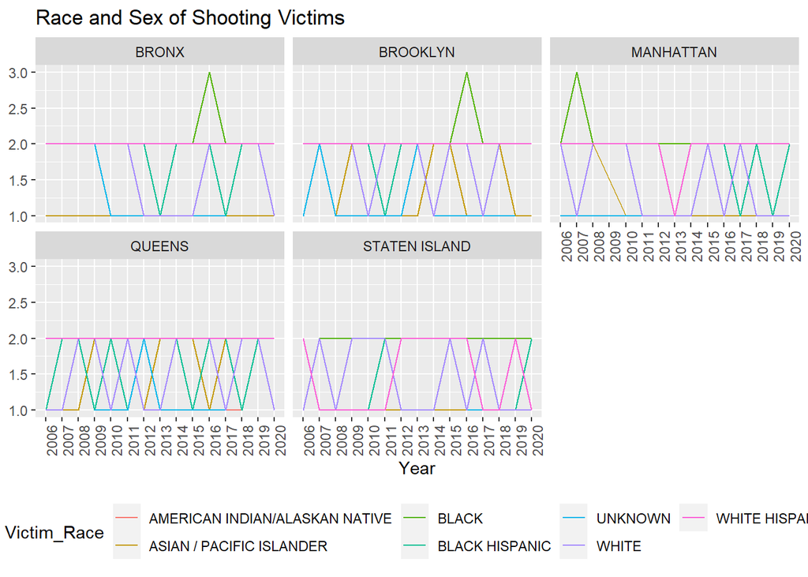

```r
ggplot(tidy_NYPD_data_final,aes(x=Year,
                                group=Victim_Race,
                                colour = Victim_Race))+
   geom_freqpoly(stat = "count",
   position="dodge", bins = 10)+
  facet_wrap(Borough~.)+
  theme(legend.position = "bottom",
        axis.text.x = element_text (angle = 90)) +
  labs(title = str_c("Race and Sex of Shooting Victims"),
       y = NULL)
```

To simplify the analyzing and modeling aspect of all three of these variables, cumulative total shootings were used in place of count and graphed and are demonstrated as followed. In this case, the dominating characteristic of each varible be seen.

```r
NYPD_data <-NYPD_data %>%
  mutate(OCCUR_DATE = mdy(OCCUR_DATE),  # convert OCCUR_DATE to date
         BORO = factor(BORO),
         VIC_SEX = factor(VIC_SEX),
         VIC_RACE = factor(VIC_RACE)) %>%
  # remove unneeded columns
  select(-c(INCIDENT_KEY,
            PRECINCT,
            JURISDICTION_CODE,
            LOCATION_DESC,
            STATISTICAL_MURDER_FLAG,
            PERP_AGE_GROUP,
            PERP_SEX,
            PERP_RACE,
            VIC_AGE_GROUP,
            X_COORD_CD,
            Y_COORD_CD,
            Latitude,
            Longitude,
            Lon_Lat))
```

```r
# sort by date
NYPD_data <- NYPD_data %>%
  arrange(OCCUR_DATE)

# convert to year again
NYPD_data <- NYPD_data %>%
  mutate(Year = floor_date(OCCUR_DATE, "year"))
NYPD_data$rec <- 1

# cuml. shootings by borough
cuml_cases_b <- NYPD_data %>%
  group_by(BORO) %>%
  mutate(Cumulative_Shootings = cumsum(rec)) %>%
  select(-rec) %>%
  ungroup()

# cuml. shootings per year
cuml_cases_by <- cuml_cases_b %>%
  group_by(Year, BORO) %>%
  top_n(1, Cumulative_Shootings) %>%
  select(c(Year, BORO, Cumulative_Shootings)) %>%
  ungroup()

# cuml. shootings by sex
cuml_cases_s <- NYPD_data %>%
  group_by(VIC_SEX) %>%
  mutate(Cumulative_Shootings = cumsum(rec)) %>%
  select(-rec) %>%
  ungroup()

# cuml. shootings per year
cuml_cases_sy <- cuml_cases_s %>%
  group_by(Year, VIC_SEX) %>%
  top_n(1, Cumulative_Shootings) %>%
  select(c(Year, VIC_SEX, Cumulative_Shootings)) %>%
  ungroup()

# cuml. shootings by borough
cuml_cases_r <- NYPD_data %>%
  group_by(VIC_RACE) %>%
  mutate(Cumulative_Shootings = cumsum(rec)) %>%
  select(-rec) %>%
  ungroup()

# cuml. shootings per year
cuml_cases_ry <- cuml_cases_r %>%
  group_by(Year, VIC_RACE) %>%
  top_n(1, Cumulative_Shootings) %>%
  select(c(Year, VIC_RACE, Cumulative_Shootings)) %>%
  ungroup()
```

```r
# separate data to individual boroughs for model
brooklyn <- cuml_cases_by %>%
  filter(BORO == "BROOKLYN")
bronx <- cuml_cases_by %>%
  filter(BORO == "BRONX")
manhattan <- cuml_cases_by %>%
  filter(BORO == "MANHATTAN")
queens <- cuml_cases_by %>%
  filter(BORO == "QUEENS")
staten_island <- cuml_cases_by %>%
  filter(BORO == "STATEN ISLAND")
```

### Visualization 7: Cumulative Shootings by Borough (2006-2020)

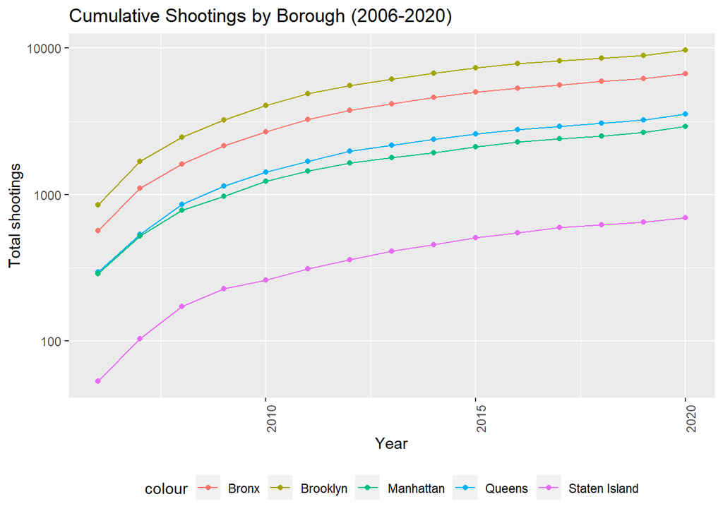

```r
brooklyn %>%
  ggplot(aes(x = Year, y = Cumulative_Shootings)) +
  geom_line(aes(color="Brooklyn")) +
  geom_point(aes(color="Brooklyn")) +
  geom_line(data=queens, aes(color="Queens")) +
  geom_point(data=queens, aes(color="Queens")) +
  geom_line(data=manhattan, aes(color="Manhattan")) +
  geom_point(data=manhattan, aes(color="Manhattan")) +
  geom_line(data=bronx, aes(color="Bronx")) +
  geom_point(data=bronx, aes(color="Bronx")) +
  geom_line(data=staten_island, aes(color="Staten Island")) +
  geom_point(data=staten_island, aes(color="Staten Island")) +
  scale_y_log10() +
  theme(legend.position="bottom",
        axis.text.x = element_text(angle=90)) +
  labs(title="Cumulative Shootings by Borough (2006-2020)",
       y="Total shootings",
       x="Year")
```

**Analysis 7: Cumulative Shootings by Borough (2006-2020)** As demonstrated in the graph above, Brooklyn is clearly the borough with the most shooting incidents. This graph also indicates over time that the amount of shootings have decreased, for the curves are all flattening for each borough.

```r
# separate data to individual boroughs for model
female <- cuml_cases_sy %>%
  filter(VIC_SEX == "F")
male <- cuml_cases_sy %>%
  filter(VIC_SEX == "M")
```

### Visualization 8: Cumulative Shootings by Sex (2006-2020)

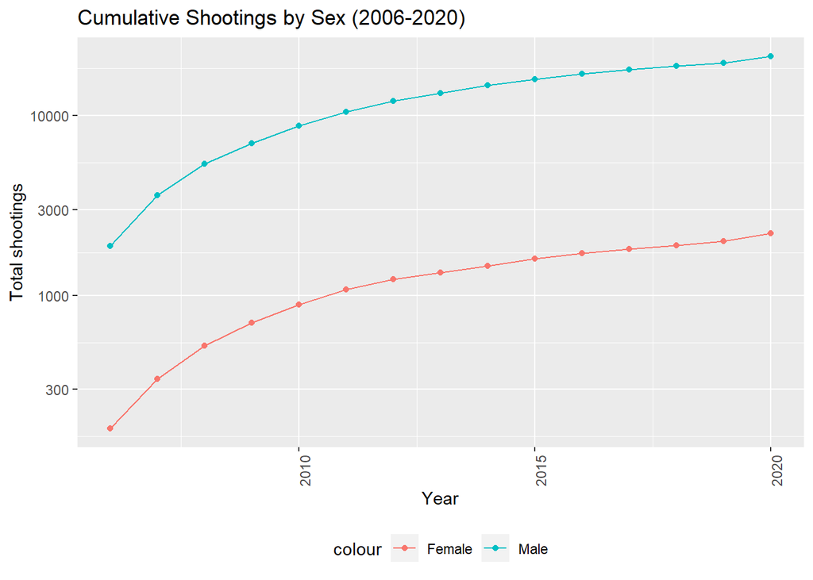

```r
female %>%
  ggplot(aes(x = Year, y = Cumulative_Shootings)) +
  geom_line(aes(color="Female")) +
  geom_point(aes(color="Female")) +
  geom_line(data=male, aes(color="Male")) +
  geom_point(data=male, aes(color="Male")) +
  scale_y_log10() +
  theme(legend.position="bottom",
        axis.text.x = element_text(angle=90)) +
  labs(title="Cumulative Shootings by Sex (2006-2020)",
       y="Total shootings",
       x="Year")
```

**Analysis 8: Cumulative Shootings by Sex (2006-2020)** Similar to the histogram, males are the ones most likely to be victims of shooting incidents. As demonstrated in the graph like the previous, despite the prominence of this trait, the number of shootings are dying down overtime.

```r
# separate data to individual boroughs for model
ai_an <- cuml_cases_ry %>%
  filter(VIC_RACE == "AMERICAN INDIAN/ALASKAN NATIVE")
asian_pi <- cuml_cases_ry %>%
  filter(VIC_RACE == "ASIAN / PACIFIC ISLANDER")
black <- cuml_cases_ry %>%
  filter(VIC_RACE == "BLACK")
black_hisp <- cuml_cases_ry %>%
  filter(VIC_RACE == "BLACK HISPANIC")
white <- cuml_cases_ry %>%
  filter(VIC_RACE == "WHITE")
white_hisp <- cuml_cases_ry %>%
  filter(VIC_RACE == "WHITE HISPANIC")
```

### Visualization 9: Cumulative Shootings by Race (2006-2020)

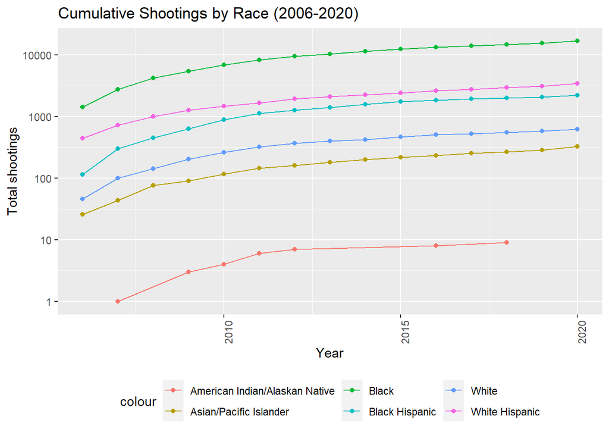

```r
ai_an %>%
  ggplot(aes(x = Year, y = Cumulative_Shootings)) +
  geom_line(aes(color="American Indian/Alaskan Native")) +
  geom_point(aes(color="American Indian/Alaskan Native")) +
  geom_line(data=asian_pi, aes(color="Asian/Pacific Islander")) +
  geom_point(data=asian_pi, aes(color="Asian/Pacific Islander")) +
  geom_line(data=black, aes(color="Black")) +
  geom_point(data=black, aes(color="Black")) +
  geom_line(data=black_hisp, aes(color="Black Hispanic")) +
  geom_point(data=black_hisp, aes(color="Black Hispanic")) +
  geom_line(data=white, aes(color="White")) +
  geom_point(data=white, aes(color="White")) +
  geom_line(data=white_hisp, aes(color="White Hispanic")) +
  geom_point(data=white_hisp, aes(color="White Hispanic")) +
  scale_y_log10() +
  theme(legend.position="bottom",
        axis.text.x = element_text(angle=90)) +
  labs(title="Cumulative Shootings by Race (2006-2020)",
       y="Total shootings",
       x="Year")
```

```r
brooklyn <- brooklyn %>%
  group_by(Year, BORO) %>%
  top_n(1, Cumulative_Shootings) %>%
  select(c(Year, BORO, Cumulative_Shootings)) %>%
  ungroup()

brooklyn <- brooklyn %>%
  mutate(Cumulative_Shootings_BY = Cumulative_Shootings)

brooklyn <- brooklyn %>%
  mutate(New_Shootings_BY = Cumulative_Shootings_BY - lag(Cumulative_Shootings_BY))
brooklyn$New_Shootings_BY <- ifelse(is.na(brooklyn$New_Shootings_BY),
                                                 brooklyn$Cumulative_Shootings_BY,
                                                 brooklyn$New_Shootings_BY)
```

## ## Modeling

For this portion, modeling was done to compare actual values to predictive values of new shooting cases over time; however due to having many variables, only the most prominent trait of each variable was seleted for modeling, which were: Brooklyn for borough location, Male for sex, and Black for race. ### Modeling 1: Brooklyn New Shooting Reports by Year Model Comparison

```r
mod_brooklyn <- lm(New_Shootings_BY ~ Year, data=brooklyn)
summary(mod_brooklyn)
```

```
##
## Call:
## lm(formula = New_Shootings_BY ~ Year, data = brooklyn)
##
## Residuals:
##     Min      1Q  Median      3Q     Max
## -174.68  -59.47   -7.33    6.05  375.18
##
## Coefficients:
##               Estimate Std. Error t value Pr(>|t|)
## (Intercept) 1909.08431  343.85504   5.552 9.35e-05 ***
## Year          -0.08024    0.02178  -3.683  0.00276 **
## ---
## Signif. codes:  0 '***' 0.001 '**' 0.01 '*' 0.05 '.' 0.1 ' ' 1
##
## Residual standard error: 133.1 on 13 degrees of freedom
## Multiple R-squared:  0.5107, Adjusted R-squared:  0.473
## F-statistic: 13.57 on 1 and 13 DF,  p-value: 0.002757
```

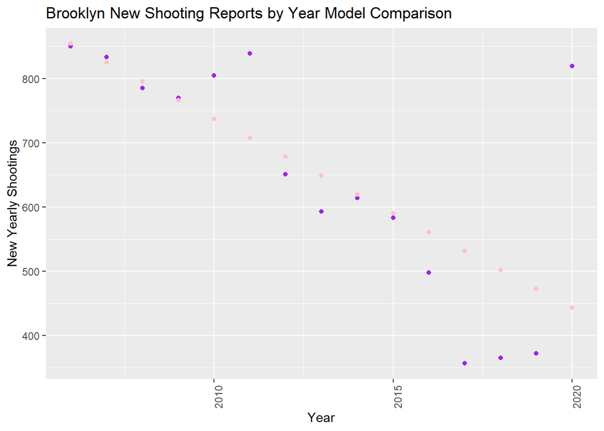

```r
brooklyn_pred <- brooklyn %>%
  mutate(pred = predict(mod_brooklyn))

brooklyn_pred %>%
  ggplot() +
  geom_point(aes(x = Year,
                 y = New_Shootings_BY),
             color = "purple") +
  geom_point(aes(x = Year, y = pred),
             color = "pink") +
  theme(legend.position="bottom",
       axis.text.x = element_text(angle=90)) +
  labs(title="Brooklyn New Shooting Reports by Year Model Comparison",
       y="New Yearly Shootings",
       x="Year")
```

**Analysis 10: Brooklyn New Shooting Reports by Year Model Comparison** In this graph, evidently there is a steep negative slope, indicating the total number of cases are likely to decrease based on the actual and predicted data, regardless if it is in Brooklyn or not.

```r
male <- male %>%
  group_by(Year, VIC_SEX) %>%
  top_n(1, Cumulative_Shootings) %>%
  select(c(Year, VIC_SEX, Cumulative_Shootings)) %>%
  ungroup()

male <- male %>%
  mutate(Cumulative_Shootings_BY = Cumulative_Shootings)

male <- male %>%
  mutate(New_Shootings_BY = Cumulative_Shootings_BY - lag(Cumulative_Shootings_BY))
male$New_Shootings_BY <- ifelse(is.na(male$New_Shootings_BY),
                                                 male$Cumulative_Shootings_BY,
                                                 male$New_Shootings_BY)
```

### Modeling 11: Male New Shooting Reports by Year Model Comparison

```r
mod_male <- lm(New_Shootings_BY ~ Year, data=male)
summary(mod_male)
```

```
##
## Call:
## lm(formula = New_Shootings_BY ~ Year, data = male)
##
## Residuals:
##     Min      1Q  Median      3Q     Max
## -299.61 -176.04  -18.60   70.03  740.52
##
## Coefficients:
##               Estimate Std. Error t value Pr(>|t|)
## (Intercept) 3993.83256  674.40902   5.922 5.05e-05 ***
## Year          -0.16358    0.04273  -3.829  0.00209 **
## ---
## Signif. codes:  0 '***' 0.001 '**' 0.01 '*' 0.05 '.' 0.1 ' ' 1
##
## Residual standard error: 261.1 on 13 degrees of freedom
## Multiple R-squared:   0.53,  Adjusted R-squared:  0.4938
## F-statistic: 14.66 on 1 and 13 DF,  p-value: 0.00209
```

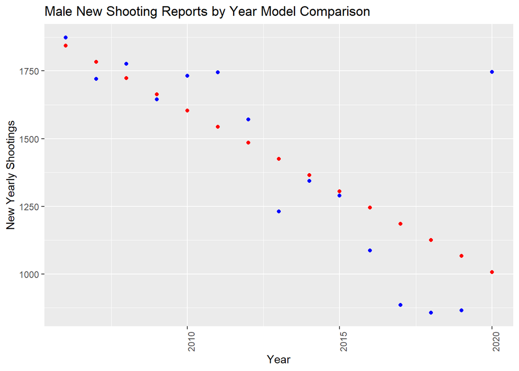

```r
male_pred <- male %>%
  mutate(pred = predict(mod_male))

male_pred %>%
  ggplot() +
  geom_point(aes(x = Year,
                 y = New_Shootings_BY),
             color = "blue") +
  geom_point(aes(x = Year, y = pred),
             color = "red") +
  theme(legend.position="bottom",
       axis.text.x = element_text(angle=90)) +
  labs(title="Male New Shooting Reports by Year Model Comparison",
       y="New Yearly Shootings",
       x="Year")
```

**Analysis 11: Male New Shooting Reports by Year Model Comparison** In this graph, evidently there is also a steep negative slope, indicating the total number of cases are likely to decrease based on the actual and predicted data, regardless if the victim at risk is male. This is vital becasue it somewhat debunks the analysis given previously stating that sex is one of the features that may instigate shooting incidents.

```r
black <- black %>%
  group_by(Year, VIC_RACE) %>%
  top_n(1, Cumulative_Shootings) %>%
  select(c(Year, VIC_RACE, Cumulative_Shootings)) %>%
  ungroup()

black <- black %>%
  mutate(Cumulative_Shootings_BY = Cumulative_Shootings)

black <- black %>%
  mutate(New_Shootings_BY = Cumulative_Shootings_BY - lag(Cumulative_Shootings_BY))
black$New_Shootings_BY <- ifelse(is.na(black$New_Shootings_BY),
                                                 black$Cumulative_Shootings_BY,
                                                 black$New_Shootings_BY)
```

### Visualization 12: Black New Shooting Reports by Year Model Comparison

```r
mod_black <- lm(New_Shootings_BY ~ Year, data=black)
summary(mod_black)
```

```
##
## Call:
## lm(formula = New_Shootings_BY ~ Year, data = black)
##
## Residuals:
##     Min      1Q  Median      3Q     Max
## -233.89 -142.47  -22.21   78.11  580.26
##
## Coefficients:
##               Estimate Std. Error t value Pr(>|t|)
## (Intercept) 3120.44312  544.24582   5.734  6.9e-05 ***
## Year          -0.12708    0.03448  -3.686  0.00274 **
## ---
## Signif. codes:  0 '***' 0.001 '**' 0.01 '*' 0.05 '.' 0.1 ' ' 1
##
## Residual standard error: 210.7 on 13 degrees of freedom
## Multiple R-squared:  0.511,  Adjusted R-squared:  0.4734
## F-statistic: 13.58 on 1 and 13 DF,  p-value: 0.002744
```

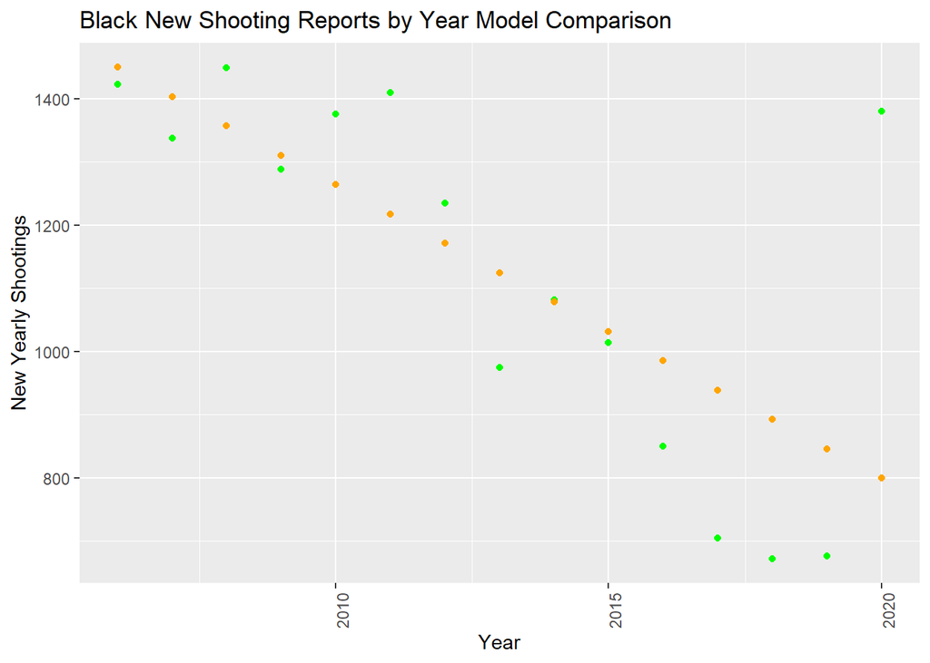

```r
black_pred <- black %>%
  mutate(pred = predict(mod_black))

black_pred %>%
  ggplot() +
  geom_point(aes(x = Year,
                 y = New_Shootings_BY),
             color = "green") +
  geom_point(aes(x = Year, y = pred),
             color = "orange") +
  theme(legend.position="bottom",
       axis.text.x = element_text(angle=90)) +
  labs(title="Black New Shooting Reports by Year Model Comparison",
       y="New Yearly Shootings",
       x="Year")
```